# 排骨玉米汤

清甜鲜香 · 暖心家常汤

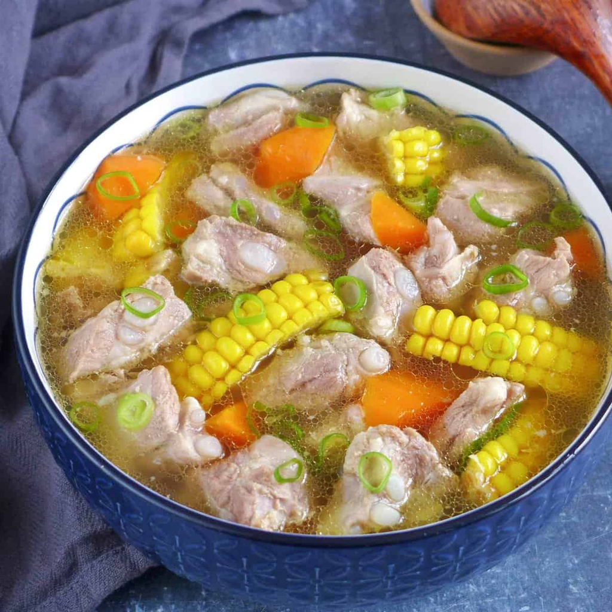

*一道简单又营养的家常汤，排骨鲜嫩，玉米清甜，胡萝卜软糯，适合全家享用。*

## 🍲 食谱信息

| 项目 | 详情 |
| --- | --- |
| **菜系** | 中式家常菜 |
| **难度** | 简单 |
| **准备时间** | 15 分钟 |
| **烹饪时间** | 约 60–90 分钟 |
| **份量** | 3–4 人份 |

## 食材准备

| 食材 | 用量 |
| --- | --- |
| 猪排骨 | 500 克 |
| 甜玉米 | 2 根 |
| 胡萝卜 | 1 根 |
| 姜 | 3–4 片 |
| 清水 | 约 1.5 升 |
| 盐 | 适量 |
| 葱段 | 少许 |
| 料酒（可选） | 少许 |
| 葱花（可选） | 少许 |

## 烹饪步骤

### 01 · 排骨焯水

排骨洗净，冷水下锅，加入姜片和少许料酒。

大火煮开后，撇去表面的浮沫，捞出排骨，用温水冲洗干净备用。

### 02 · 准备配菜

- 玉米切成小段。
- 胡萝卜去皮，切滚刀块。
- 葱切段，姜切片。

### 03 · 炖煮汤底

将焯水后的排骨放入汤锅中，加入葱段、姜片和约 1.5 升清水。

大火煮开后转小火，盖上锅盖慢炖约 20 分钟。

### 04 · 加入玉米与胡萝卜

放入玉米段和胡萝卜块，继续小火慢炖。

让玉米的清甜味和排骨的鲜香慢慢融入汤中。

继续炖煮约 30–60 分钟，直到排骨软烂。

### 05 · 调味

待排骨炖至软嫩，玉米和胡萝卜熟透后，加入适量盐。

可以先加入约 1 小勺，再根据个人口味调整。

### 06 · 出锅享用

继续煮 2–3 分钟，让汤汁充分入味。

关火后盛入汤碗，喜欢的话撒上少许葱花即可。

## 烹饪小贴士

**让汤更清澈**

排骨提前冷水焯水，并冲洗去除浮沫，可以让汤色更加清亮。

**让排骨更软嫩**

小火慢炖，避免持续大火滚煮。根据排骨大小适当延长时间。

**保留玉米的自然甜味**

尽量在出锅前再加盐，让食材的自然鲜甜更加突出。

*简单的食材，慢慢炖煮，就是一碗温暖的家的味道。*